# 실전데이타분석

## 6. CCTV와 인구현황 그래프로 분석하기

```python
# CCTV 현황과 서울시 인구 현황 최종 데이타 확인
data_result.head()
```

| 구별 | 소계 | 최근증가율 | 인구수 | 한국인 | 외국인 | 고령자 | 외국인비율 | 고령자비율 |
| --- | --- | --- | --- | --- | --- | --- | --- | --- |
| 강남구 | 3238 | 150.619195 | 549255 | 544257 | 4998 | 66412 | 0.909960 | 12.091287 |
| 강동구 | 1010 | 166.490765 | 434992 | 430705 | 4287 | 58280 | 0.985535 | 13.397948 |
| 강북구 | 831 | 125.203252 | 324276 | 320576 | 3700 | 57741 | 1.141003 | 17.806128 |
| 강서구 | 911 | 134.793814 | 605068 | 598416 | 6652 | 78814 | 1.099381 | 13.025643 |
| 관악구 | 2109 | 149.290780 | 521685 | 503956 | 17729 | 71840 | 3.398411 | 13.770762 |

```python
import matplotlib.pyplot as plt
```

```python
# 한글 폰트 설정
import platform

from matplotlib import font_manager, rc
plt.rcParams['axes.unicode_minus'] = False

if platform.system() == 'Darwin':    # 맥OS인 경우 폰트 변경
    rc('font', family='AppleGothic')
elif platform.system() == 'Windows': # 윈도우인 경우 폰트 변경
    path = "c:/Windows/Fonts/malgun.ttf"
    font_name = font_manager.FontProperties(fname=path).get_name()
    rc('font', family=font_name)
else:
    print('Unknown system... sorry~~~~')
```

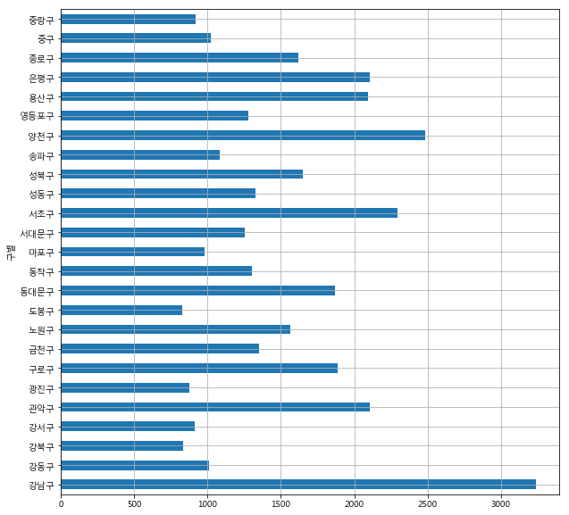

```python
# pandas 데이타 뒤에 plot 명령, 그래프 종류-수평바 그래프
plt.figure()
data_result['소계'].plot(kind='barh', grid=True, figsize=(10,10))
plt.show()
```

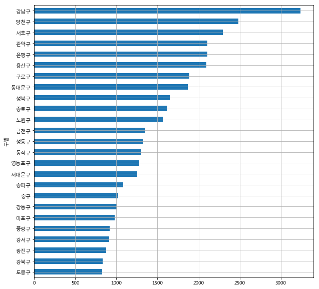

```python
# 수평바 그래프 - 데이타 정렬되어 있으면 효과가 더 좋음
data_result['소계'].sort_values().plot(kind='barh',
                                     grid=True, figsize=(10,10))
plt.show()
```

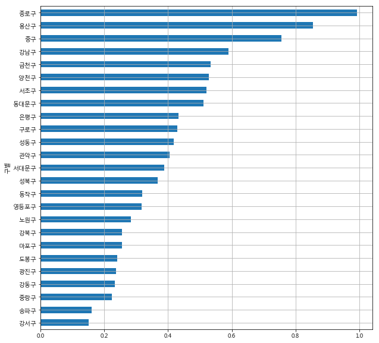

```python
# 인구 대비 CCTV 비율을 계산해서 정렬
data_result['CCTV비율'] = data_result['소계'] / data_result['인구수'] * 100

data_result['CCTV비율'].sort_values().plot(kind='barh',
                                         grid=True, figsize=(10,10))
plt.show()
```

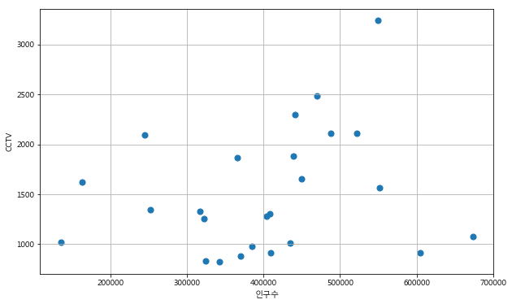

```python
# scatter 그래프, s=50 마커의 크기 지정
plt.figure(figsize=(10,6))
plt.scatter(data_result['인구수'], data_result['소계'], s=50)
plt.xlabel('인구수')
plt.ylabel('CCTV')
plt.grid()
plt.show()
```

```python
# CCTV와 인구수는 양의 상관관계를 가진다는 것이 전제
# numpy의 polyfit 명령으로 손쉽게 직선을 그릴 수 있다.
fp1 = np.polyfit(data_result['인구수'], data_result['소계'], 1)
fp1
```

[output not shown]

```python
f1 = np.poly1d(fp1)
fx = np.linspace(100000, 700000, 100)
```

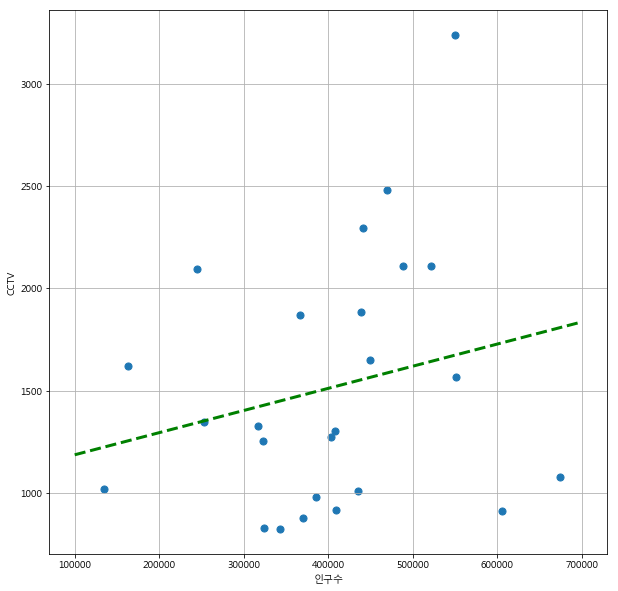

```python
plt.figure(figsize=(10,10))
plt.scatter(data_result['인구수'], data_result['소계'], s=50)
plt.plot(fx, f1(fx), ls='dashed', lw=3, color='g')
plt.xlabel('인구수')
plt.ylabel('CCTV')
plt.grid()
plt.show()
```

## 7. 조금더 설득력 있는 자료 만들기

### - 구별 인구수와 CCTV 수를 그래프에 같이 그리기

```python
fp1 = np.polyfit(data_result['인구수'], data_result['소계'], 1)

f1 = np.poly1d(fp1)
fx = np.linspace(100000, 700000, 100)

data_result['오차'] = np.abs(data_result['소계'] - f1(data_result['인구수']))

df_sort = data_result.sort_values(by='오차', ascending=False)
df_sort.head()
```

| 구별 | 소계 | 최근증가율 | 인구수 | 한국인 | 외국인 | 고령자 | 외국인비율 | 고령자비율 | CCTV비율 | 오차 |
| --- | --- | --- | --- | --- | --- | --- | --- | --- | --- | --- |
| 강남구 | 3238 | 150.619195 | 549255 | 544257 | 4998 | 66412 | 0.909960 | 12.091287 | 0.589526 | 1564.173631 |
| 양천구 | 2482 | 34.671731 | 469945 | 466121 | 3824 | 57442 | 0.813712 | 12.223132 | 0.528147 | 893.971889 |
| 강서구 | 911 | 134.793814 | 605068 | 598416 | 6652 | 78814 | 1.099381 | 13.025643 | 0.150562 | 823.205365 |
| 용산구 | 2096 | 53.216374 | 245087 | 229391 | 15696 | 37443 | 6.404256 | 15.277432 | 0.855207 | 751.225257 |
| 서초구 | 2297 | 63.371266 | 441539 | 437407 | 4132 | 54887 | 0.935818 | 12.430838 | 0.520226 | 739.701750 |

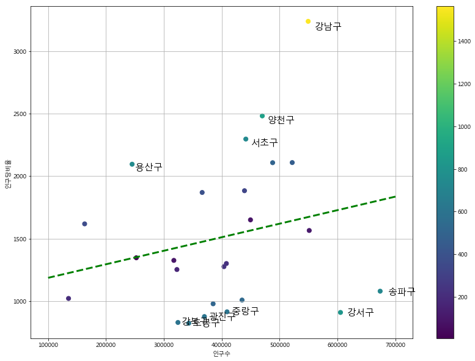

```python
plt.figure(figsize=(14,10))
plt.scatter(data_result['인구수'], data_result['소계'],
            c=data_result['오차'], s=50)
plt.plot(fx, f1(fx), ls='dashed', lw=3, color='g')

for n in range(10):
    plt.text(df_sort['인구수'][n]*1.02, df_sort['소계'][n]*0.98,
             df_sort.index[n], fontsize=15)

plt.xlabel('인구수')
plt.ylabel('인구당비율')
plt.colorbar()
plt.grid()
plt.show()
```

* 서울시에서 다른 구와 비교했을 때, 강남구, 양천구, 서초구, 용산구는 CCTV가 많지만, * 송파구, 강서구, 도봉구, 광진구, 중랑구, 강북구는 다른 구에 비해 CCTV 비율이 낮다.

## 8. 구별 CCTV 지도 시각화

```python
# 지도 시각화를 위한 모듈 import
import folium
```

- 한국 지도 josn 파일 - https://github.com/southkorea/southkorea-maps

```python
import json

# 서울시 구별 지도 json 파일 가져오기
geo_path = '../data/skorea_municipalities_geo_simple.json'
geo_str = json.load(open(geo_path, encoding='utf-8'))
```

```python
# 경고 메세지 무시
import warnings
warnings.filterwarnings(action='ignore')
```

```python
# 서울시 중심의 위도와 경도 정보 입력하고 경계선 그리고 컬러맵은 CCTV소계로 지정
map = folium.Map(location=[37.5502, 126.982], zoom_start=11,
                 tiles='Stamen Toner')

map.choropleth(geo_data = geo_str,
               data = data_result['소계'],
               columns = [data_result.index, data_result['소계']],
               fill_color = 'YlGnBu', #PuRd, YlGnBu
               key_on = 'feature.id')
map
```

[interactive chart not shown]

- CCTV 개수는 강남구 > 양천구 > 서초구.. 등 순으로 많아 보임

```python
# 서울시 구별 인구수로 컬러맵 지정
map = folium.Map(location=[37.5502, 126.982], zoom_start=11,
                 tiles='Stamen Toner')

map.choropleth(geo_data = geo_str,
               data = data_result['인구수'],
               columns = [data_result.index, data_result['인구수']],
               fill_color = 'YlGnBu', #PuRd, YlGnBu
               key_on = 'feature.id')
map
```

[interactive chart not shown]

- 서울시 구별 인구수 : 송파구 > 강서구 > 노원구 > 강남구 > 관악구...

```python
# 서울시 구별 고령자수로 컬러맵 지정
map = folium.Map(location=[37.5502, 126.982], zoom_start=11,
                 tiles='Stamen Toner')

map.choropleth(geo_data = geo_str,
               data = data_result['고령자'],
               columns = [data_result.index, data_result['고령자']],
               fill_color = 'YlGnBu', #PuRd, YlGnBu
               key_on = 'feature.id')
map
```

[interactive chart not shown]

- 서울시 구별 고령자수 : 송파구 > 강서구 > 은평구 > 노원구 > 관악구 ...

```python
# 서울시 구별 CCTV 비율로 컬러맵 지정
map = folium.Map(location=[37.5502, 126.982], zoom_start=11,
                 tiles='Stamen Toner')

map.choropleth(geo_data = geo_str,
               data = data_result['CCTV비율'],
               columns = [data_result.index, data_result['CCTV비율']],
               fill_color = 'YlGnBu', #PuRd, YlGnBu
               key_on = 'feature.id')
map
```

[interactive chart not shown]

- 서울시 구별 CCTV 비율 : 종로구 > 용산구 > 중구 > 강남구 ..

## 9. 서울시 구별 CCTV 현황과 인구수를 동시에 지도에 시각화하기

- 지도 정보(위도, 경도)를 얻기 위한 Google Maps API 이용
- 데이타프레임에 위도, 경도, 주소 컬럼 추가
- 서울시 구별 지도에 CCTV 개수 표시
- 서울시 구별 지도에 인구수 표시

```python
# pip install googlemaps
import googlemaps
```

- Google Maps API 사이트 : https://cloud.google.com/maps-platform/?hl=ko
- 참고 사이트 : https://pinkwink.kr/1143

```python
# 받아온 goolge gmap key 입력
gmaps_key = " 자신의 key를 사용합니다."
gmaps = googlemaps.Client(key=gmaps_key)
```

```python
# 예제로 '강남구청' 입력 -> 주소, 위도, 경도 확인
gmaps.geocode('강남구청', language='ko')
```

```
[{'address_components': [{'long_name': '４２６',
    'short_name': '４２６',
    'types': ['premise']},
   {'long_name': '학동로',
    'short_name': '학동로',
    'types': ['political', 'sublocality', 'sublocality_level_4']},
   {'long_name': '삼성2동',
    'short_name': '삼성2동',
    'types': ['political', 'sublocality', 'sublocality_level_2']},
   {'long_name': '강남구',
    'short_name': '강남구',
    'types': ['political', 'sublocality', 'sublocality_level_1']},
   {'long_name': '서울특별시',
    'short_name': '서울특별시',
    'types': ['administrative_area_level_1', 'political']},
   {'long_name': '대한민국',
    'short_name': 'KR',
    'types': ['country', 'political']},
   {'long_name': '135-092',
    'short_name': '135-092',
    'types': ['postal_code']}],
  'formatted_address': '대한민국 서울특별시 강남구 삼성2동 학동로 426',
  'geometry': {'location': {'lat': 37.517351, 'lng': 127.0474381},
   'location_type': 'ROOFTOP',
   'viewport': {'northeast': {'lat': 37.51869998029149,
     'lng': 127.0487870802915},
    'southwest': {'lat': 37.51600201970849, 'lng': 127.0460891197085}}},
  'place_id': 'ChIJ6d50xnOkfDUR83ji1C1-2N4',
  'plus_code': {'compound_code': 'G28W+WX 대한민국 서울특별시',
   'global_code': '8Q99G28W+WX'},
  'types': ['establishment', 'local_government_office', 'point_of_interest']}]
```

```python
# 원본 pandas 파일 확인
df_sort.head()
```

| 구별 | 소계 | 최근증가율 | 인구수 | 한국인 | 외국인 | 고령자 | 외국인비율 | 고령자비율 | CCTV비율 | 오차 |
| --- | --- | --- | --- | --- | --- | --- | --- | --- | --- | --- |
| 강남구 | 3238 | 150.619195 | 549255 | 544257 | 4998 | 66412 | 0.909960 | 12.091287 | 0.589526 | 1564.173631 |
| 양천구 | 2482 | 34.671731 | 469945 | 466121 | 3824 | 57442 | 0.813712 | 12.223132 | 0.528147 | 893.971889 |
| 강서구 | 911 | 134.793814 | 605068 | 598416 | 6652 | 78814 | 1.099381 | 13.025643 | 0.150562 | 823.205365 |
| 용산구 | 2096 | 53.216374 | 245087 | 229391 | 15696 | 37443 | 6.404256 | 15.277432 | 0.855207 | 751.225257 |
| 서초구 | 2297 | 63.371266 | 441539 | 437407 | 4132 | 54887 | 0.935818 | 12.430838 | 0.520226 | 739.701750 |

```python
# 서울시 구별 중심 좌표를 각 구청으로 설정 : 강남구 -> 강남구청
gu_name = []

for name in data_result.index:
    gu_name.append(str(name) + '청')

gu_name
```

```
['강남구청',
 '강동구청',
 '강북구청',
 '강서구청',
 '관악구청',
 '광진구청',
 '구로구청',
 '금천구청',
 '노원구청',
 '도봉구청',
 '동대문구청',
 '동작구청',
 '마포구청',
 '서대문구청',
 '서초구청',
 '성동구청',
 '성북구청',
 '송파구청',
 '양천구청',
 '영등포구청',
 '용산구청',
 '은평구청',
 '종로구청',
 '중구청',
 '중랑구청']
```

```python
# 각 구청별 주소, 위도, 경도 알아내기
gu_address = []
gu_lat = []
gu_lng = []

for name in gu_name:
    tmp = gmaps.geocode(name, language='ko')
    gu_address.append(tmp[0].get("formatted_address"))

    tmp_loc = tmp[0].get("geometry")

    gu_lat.append(tmp_loc['location']['lat'])
    gu_lng.append(tmp_loc['location']['lng'])

    print(name + '-->' + tmp[0].get("formatted_address"))
```

```
강남구청-->대한민국 서울특별시 강남구 삼성2동 학동로 426
강동구청-->대한민국 서울특별시 강동구 성내동 성내로 25
강북구청-->대한민국 서울특별시 강북구 수유동 도봉로89길 13
강서구청-->대한민국 서울특별시 강서구 화곡동 화곡로 302
관악구청-->대한민국 서울특별시 관악구 관악로 145
광진구청-->대한민국 서울특별시 광진구 자양1동 자양로 117
구로구청-->대한민국 서울특별시 구로구 구로동 가마산로 245
금천구청-->대한민국 서울특별시 금천구
노원구청-->대한민국 서울특별시 노원구 상계6.7동 노해로 437
도봉구청-->대한민국 서울특별시 도봉구 방학동 마들로 656
동대문구청-->대한민국 서울특별시 동대문구 용두동 천호대로 145
동작구청-->대한민국 서울특별시 동작구 노량진2동 장승배기로 161
마포구청-->대한민국 서울특별시 마포구 성산2동 월드컵로 212
서대문구청-->대한민국 서울특별시 서대문구 연희동 연희로 248
서초구청-->대한민국 서울특별시 서초구 서초2동 남부순환로 2584
성동구청-->대한민국 서울특별시 성동구 행당동 고산자로 270
성북구청-->대한민국 서울특별시 성북구 삼선동 보문로 168
송파구청-->대한민국 서울특별시 송파구 신천동 올림픽로 326
양천구청-->대한민국 서울특별시 양천구 신정6동 목동동로 105
영등포구청-->대한민국 서울특별시 영등포구 당산동3가 당산로 123
용산구청-->대한민국 서울특별시 용산구 이태원동 녹사평대로 150
은평구청-->대한민국 서울특별시 은평구 녹번동 은평로 195
종로구청-->대한민국 서울특별시 종로구 수송동 삼봉로 43
중구청-->대한민국 서울특별시 중구 예관동 창경궁로 17
중랑구청-->대한민국 서울특별시 중랑구 신내동 662
```

```python
# 각 구청 주소 확인
gu_address
```

```
['대한민국 서울특별시 강남구 삼성2동 학동로 426',
 '대한민국 서울특별시 강동구 성내동 성내로 25',
 '대한민국 서울특별시 강북구 수유동 도봉로89길 13',
 '대한민국 서울특별시 강서구 화곡동 화곡로 302',
 '대한민국 서울특별시 관악구 관악로 145',
 '대한민국 서울특별시 광진구 자양1동 자양로 117',
 '대한민국 서울특별시 구로구 구로동 가마산로 245',
 '대한민국 서울특별시 금천구',
 '대한민국 서울특별시 노원구 상계6.7동 노해로 437',
 '대한민국 서울특별시 도봉구 방학동 마들로 656',
 '대한민국 서울특별시 동대문구 용두동 천호대로 145',
 '대한민국 서울특별시 동작구 노량진2동 장승배기로 161',
 '대한민국 서울특별시 마포구 성산2동 월드컵로 212',
 '대한민국 서울특별시 서대문구 연희동 연희로 248',
 '대한민국 서울특별시 서초구 서초2동 남부순환로 2584',
 '대한민국 서울특별시 성동구 행당동 고산자로 270',
 '대한민국 서울특별시 성북구 삼선동 보문로 168',
 '대한민국 서울특별시 송파구 신천동 올림픽로 326',
 '대한민국 서울특별시 양천구 신정6동 목동동로 105',
 '대한민국 서울특별시 영등포구 당산동3가 당산로 123',
 '대한민국 서울특별시 용산구 이태원동 녹사평대로 150',
 '대한민국 서울특별시 은평구 녹번동 은평로 195',
 '대한민국 서울특별시 종로구 수송동 삼봉로 43',
 '대한민국 서울특별시 중구 예관동 창경궁로 17',
 '대한민국 서울특별시 중랑구 신내동 662']
```

```python
# 각 구청 위도 확인
gu_lat
```

```
[37.517351,
 37.5301756,
 37.6397767,
 37.5509103,
 37.4781285,
 37.5385333,
 37.4954703,
 37.4518527,
 37.6540471,
 37.6687735,
 37.5744155,
 37.5124018,
 37.5662001,
 37.57917279999999,
 37.483574,
 37.5630725,
 37.589366,
 37.5144161,
 37.5169508,
 37.526344,
 37.5325896,
 37.6027496,
 37.5727864,
 37.5637584,
 37.60656]
```

```python
# 각 구청 경도 확인
gu_lng
```

```
[127.0474381,
 127.1237721,
 127.0255184,
 126.8495742,
 126.9515024,
 127.0823772,
 126.8876391,
 126.9020358,
 127.0563372,
 127.047071,
 127.0397427,
 126.9394748,
 126.9016437,
 126.9367815,
 127.032661,
 127.0366688,
 127.016743,
 127.1060657,
 126.8665644,
 126.896256,
 126.9900429,
 126.9292386,
 126.9791778,
 126.9975517,
 127.092624]
```

```python
# 원본 pandas 파일 확인
df_sort.head()
```

| 구별 | 소계 | 최근증가율 | 인구수 | 한국인 | 외국인 | 고령자 | 외국인비율 | 고령자비율 | CCTV비율 | 오차 |
| --- | --- | --- | --- | --- | --- | --- | --- | --- | --- | --- |
| 강남구 | 3238 | 150.619195 | 549255 | 544257 | 4998 | 66412 | 0.909960 | 12.091287 | 0.589526 | 1564.173631 |
| 양천구 | 2482 | 34.671731 | 469945 | 466121 | 3824 | 57442 | 0.813712 | 12.223132 | 0.528147 | 893.971889 |
| 강서구 | 911 | 134.793814 | 605068 | 598416 | 6652 | 78814 | 1.099381 | 13.025643 | 0.150562 | 823.205365 |
| 용산구 | 2096 | 53.216374 | 245087 | 229391 | 15696 | 37443 | 6.404256 | 15.277432 | 0.855207 | 751.225257 |
| 서초구 | 2297 | 63.371266 | 441539 | 437407 | 4132 | 54887 | 0.935818 | 12.430838 | 0.520226 | 739.701750 |

```python
# 원본 pandas 파일인 df_sort를 "구별"로 오름차순 정렬하여 df_sort2로 복사
df_sort2 = df_sort.sort_values(by="구별", ascending=True)
df_sort2.head()
```

| 구별 | 소계 | 최근증가율 | 인구수 | 한국인 | 외국인 | 고령자 | 외국인비율 | 고령자비율 | CCTV비율 | 오차 |
| --- | --- | --- | --- | --- | --- | --- | --- | --- | --- | --- |
| 강남구 | 3238 | 150.619195 | 549255 | 544257 | 4998 | 66412 | 0.909960 | 12.091287 | 0.589526 | 1564.173631 |
| 강동구 | 1010 | 166.490765 | 434992 | 430705 | 4287 | 58280 | 0.985535 | 13.397948 | 0.232188 | 540.215648 |
| 강북구 | 831 | 125.203252 | 324276 | 320576 | 3700 | 57741 | 1.141003 | 17.806128 | 0.256263 | 599.442102 |
| 강서구 | 911 | 134.793814 | 605068 | 598416 | 6652 | 78814 | 1.099381 | 13.025643 | 0.150562 | 823.205365 |
| 관악구 | 2109 | 149.290780 | 521685 | 503956 | 17729 | 71840 | 3.398411 | 13.770762 | 0.404267 | 464.999100 |

```python
# 구별로 소팅된 pandas에 구청, 위도, 경도, 주소 컬럼 추가
df_sort2['구청'] = gu_name
df_sort2['lat'] = gu_lat
df_sort2['lng'] = gu_lng
df_sort2['address'] = gu_address
```

```python
# 추가된 컬럼 확인
df_sort2.head()
```

| 구별 | 소계 | 최근증가율 | 인구수 | 한국인 | 외국인 | 고령자 | 외국인비율 | 고령자비율 | CCTV비율 | 오차 | 구청 | lat | lng | address |
| --- | --- | --- | --- | --- | --- | --- | --- | --- | --- | --- | --- | --- | --- | --- |
| 강남구 | 3238 | 150.619195 | 549255 | 544257 | 4998 | 66412 | 0.909960 | 12.091287 | 0.589526 | 1564.173631 | 강남구청 | 37.517351 | 127.047438 | 대한민국 서울특별시 강남구 삼성2동 학동로 426 |
| 강동구 | 1010 | 166.490765 | 434992 | 430705 | 4287 | 58280 | 0.985535 | 13.397948 | 0.232188 | 540.215648 | 강동구청 | 37.530176 | 127.123772 | 대한민국 서울특별시 강동구 성내동 성내로 25 |
| 강북구 | 831 | 125.203252 | 324276 | 320576 | 3700 | 57741 | 1.141003 | 17.806128 | 0.256263 | 599.442102 | 강북구청 | 37.639777 | 127.025518 | 대한민국 서울특별시 강북구 수유동 도봉로89길 13 |
| 강서구 | 911 | 134.793814 | 605068 | 598416 | 6652 | 78814 | 1.099381 | 13.025643 | 0.150562 | 823.205365 | 강서구청 | 37.550910 | 126.849574 | 대한민국 서울특별시 강서구 화곡동 화곡로 302 |
| 관악구 | 2109 | 149.290780 | 521685 | 503956 | 17729 | 71840 | 3.398411 | 13.770762 | 0.404267 | 464.999100 | 관악구청 | 37.478128 | 126.951502 | 대한민국 서울특별시 관악구 관악로 145 |

```python
# 구청별 주소와 위도, 경도 컬럼 추가한 pandas csv 형태로 외부로 보내기
import pandas as pd

df = df_sort2.copy()
df.to_csv("../data/cctvandseoul.csv")
```

## 여기서부터 위도, 경도가 첨가된 csv 파일을 불러와서 진행합니다..

```python
# 최종 정리된 csv 파일 불러오기
df_sort2 = pd.read_csv("../data/cctvandseoul.csv")
df_sort2.head(3)
```

|  | 구별 | 소계 | 최근증가율 | 인구수 | 한국인 | 외국인 | 고령자 | 외국인비율 | 고령자비율 | CCTV비율 | 오차 | 구청 | lat | lng | address |
| --- | --- | --- | --- | --- | --- | --- | --- | --- | --- | --- | --- | --- | --- | --- | --- |
| 0 | 강남구 | 3238 | 150.619195 | 549255 | 544257 | 4998 | 66412 | 0.909960 | 12.091287 | 0.589526 | 1564.173631 | 강남구청 | 37.517351 | 127.047438 | 대한민국 서울특별시 강남구 삼성2동 학동로 426 |
| 1 | 강동구 | 1010 | 166.490765 | 434992 | 430705 | 4287 | 58280 | 0.985535 | 13.397948 | 0.232188 | 540.215648 | 강동구청 | 37.530176 | 127.123772 | 대한민국 서울특별시 강동구 성내동 성내로 25 |
| 2 | 강북구 | 831 | 125.203252 | 324276 | 320576 | 3700 | 57741 | 1.141003 | 17.806128 | 0.256263 | 599.442102 | 강북구청 | 37.639777 | 127.025518 | 대한민국 서울특별시 강북구 수유동 도봉로89길 13 |

```python
# '구별' 컬럼을 index로 설정 : set_index 명령
df_sort2.set_index('구별', inplace=True)
df_sort2.head(3)
```

| 구별 | 소계 | 최근증가율 | 인구수 | 한국인 | 외국인 | 고령자 | 외국인비율 | 고령자비율 | CCTV비율 | 오차 | 구청 | lat | lng | address |
| --- | --- | --- | --- | --- | --- | --- | --- | --- | --- | --- | --- | --- | --- | --- |
| 강남구 | 3238 | 150.619195 | 549255 | 544257 | 4998 | 66412 | 0.909960 | 12.091287 | 0.589526 | 1564.173631 | 강남구청 | 37.517351 | 127.047438 | 대한민국 서울특별시 강남구 삼성2동 학동로 426 |
| 강동구 | 1010 | 166.490765 | 434992 | 430705 | 4287 | 58280 | 0.985535 | 13.397948 | 0.232188 | 540.215648 | 강동구청 | 37.530176 | 127.123772 | 대한민국 서울특별시 강동구 성내동 성내로 25 |
| 강북구 | 831 | 125.203252 | 324276 | 320576 | 3700 | 57741 | 1.141003 | 17.806128 | 0.256263 | 599.442102 | 강북구청 | 37.639777 | 127.025518 | 대한민국 서울특별시 강북구 수유동 도봉로89길 13 |

```python
# pip install folium
# 서울 구별 지도에 구청의 위도와 경도를 이용하여 마커로 표시하기
map = folium.Map(location=[37.5502, 126.982], zoom_start=11)

for n in df_sort2.index:
    folium.Marker([df_sort2['lat'][n],df_sort2['lng'][n]],
                      icon=folium.Icon(icon='star')).add_to(map)
map
```

[interactive chart not shown]

```python
from IPython.display import HTML
import folium

def display(m, height=500):
    """Takes a folium instance and embed HTML."""
    m._build_map()
    srcdoc = m.HTML.replace('"', '&quot;')
    embed = HTML('<iframe srcdoc="{0}" '
                 'style="width: 100%; height: {1}px; '
                 'border: none"></iframe>'.format(srcdoc, height))
    return embed
```

```python
folium.__version__
```

```
'0.9.1'
```

```python
import pandas as pd

SF_COORDINATES = (37.5502, 126.982)
df_sort2.head(4)
```

| 구별 | 소계 | 최근증가율 | 인구수 | 한국인 | 외국인 | 고령자 | 외국인비율 | 고령자비율 | CCTV비율 | 오차 | 구청 | lat | lng | address |
| --- | --- | --- | --- | --- | --- | --- | --- | --- | --- | --- | --- | --- | --- | --- |
| 강남구 | 3238 | 150.619195 | 549255 | 544257 | 4998 | 66412 | 0.909960 | 12.091287 | 0.589526 | 1564.173631 | 강남구청 | 37.517351 | 127.047438 | 대한민국 서울특별시 강남구 삼성2동 학동로 426 |
| 강동구 | 1010 | 166.490765 | 434992 | 430705 | 4287 | 58280 | 0.985535 | 13.397948 | 0.232188 | 540.215648 | 강동구청 | 37.530176 | 127.123772 | 대한민국 서울특별시 강동구 성내동 성내로 25 |
| 강북구 | 831 | 125.203252 | 324276 | 320576 | 3700 | 57741 | 1.141003 | 17.806128 | 0.256263 | 599.442102 | 강북구청 | 37.639777 | 127.025518 | 대한민국 서울특별시 강북구 수유동 도봉로89길 13 |
| 강서구 | 911 | 134.793814 | 605068 | 598416 | 6652 | 78814 | 1.099381 | 13.025643 | 0.150562 | 823.205365 | 강서구청 | 37.550910 | 126.849574 | 대한민국 서울특별시 강서구 화곡동 화곡로 302 |

```python
# 마커에 팝업으로 CCTV 개수 보여주기
map = folium.Map(location=[37.5502, 126.982], zoom_start=11)

folium.Marker([37.517351,127.047438],
                  popup = '강남구 CCTV: 3238').add_to(map)
folium.Marker([37.530264,127.123796],
                  popup = '강동구 CCTV: 1010').add_to(map)
map
```

[interactive chart not shown]

```python
# 각 구별 CCTV 비율을 지도에 표시하기
map = folium.Map(location=[37.5502, 126.982], zoom_start=11)

for n in df_sort2.index:
    folium.CircleMarker([df_sort2['lat'][n], df_sort2['lng'][n]],
                        radius = df_sort2['CCTV비율'][n]*40,
                        color='#3186cc', fill_color='#3186cc', fill=True).add_to(map)
map
```

[interactive chart not shown]

```python
# 각구별 인구수는 컬러맵으로 표시하고, CCTV 비율은 Circle Marker로 표시
map = folium.Map(location=[37.5502, 126.982], zoom_start=11)

map.choropleth(geo_data = geo_str,
               data = data_result['인구수'],
               columns = [data_result.index, data_result['인구수']],
               fill_color = 'YlGnBu', #PuRd, YlGnBu
               key_on = 'feature.id')

for n in df_sort2.index:
    folium.CircleMarker([df_sort2['lat'][n], df_sort2['lng'][n]],
                        radius = df_sort2['CCTV비율'][n]*40,
                        color='#3186cc', fill_color='#3186cc', fill=True).add_to(map)

map
```

[interactive chart not shown]

```python
# 각구별 인구수는 컬러맵으로 표시하고, CCTV 비율은 Circle Marker로 표시
map = folium.Map(location=[37.5502, 126.982], zoom_start=11)

map.choropleth(geo_data = geo_str,
               data = df_sort2['인구수'],
               columns = [df_sort2.index, df_sort2['인구수']], fill_opacity=0.4, line_opacity=0.7,
               fill_color = 'YlGnBu', #PuRd, YlGnBu
               key_on = 'feature.id')

for n in df_sort2.index:
    folium.CircleMarker([df_sort2['lat'][n], df_sort2['lng'][n]],
                        radius = df_sort2['CCTV비율'][n]*40,
                        color='#3186cc', fill_color='#3186cc', fill=True).add_to(map)

map
```

[interactive chart not shown]

```python
# 각구별 인구수는 컬러맵으로 표시하고, CCTV 비율은 Circle Marker로 표시, Marker로 CCTV개수 표시
map = folium.Map(location=[37.5502, 126.982], zoom_start=11)

map.choropleth(geo_data = geo_str,
               data = df_sort2['인구수'],
               columns = [df_sort2.index, df_sort2['인구수']],
               fill_color = 'PuRd', #PuRd, YlGnBu
               key_on = 'feature.id')

for n in df_sort2.index:
    folium.CircleMarker([df_sort2['lat'][n], df_sort2['lng'][n]],
                        radius = df_sort2['CCTV비율'][n]*40,
                        color='#3186cc', fill_color='#3186cc', fill=True).add_to(map)

folium.Marker([37.517351,127.047438],
                  popup = '강남구 CCTV: 3,238', icon=folium.Icon(color='green')).add_to(map)
folium.Marker([37.514416,127.106066],
                  popup = '송파구 CCTV: 1081', icon=folium.Icon(color='red', icon='info-sign')).add_to(map)

map
```

[interactive chart not shown]

```python
## 혼자 해보기 - 서울시 무인발급기 위치 안내
# - https://www.minwon.go.kr/new_info/customer/AA090_CM010_No_man_popup.jsp
```